# Exercise 2

2022-04-29

Task 1: Import Data

```r
## Load the necessary libraries ################################################

library(readr)        # to import tabular data (e.g. csv)
library(dplyr)        # to manipulate (tabular) data
```

```r
library(ggplot2)      # to visualize data
library(sf)           # to handle spatial vector data
library(terra)        # To handle raster data
library(lubridate)    # To handle dates and times

## Import the downloaded csv ##################################################

wildschwein_BE <- read_delim("wildschwein_BE_2056.csv",",")

wildschwein_BE <- st_as_sf(wildschwein_BE, coords = c("E", "N"), crs = 2056, remove = FALSE)
```

Task 2: Getting an overview

```r
wildschwein_BE
```

```
## Simple feature collection with 51246 features and 6 fields
## Geometry type: POINT
## Dimension:     XY
## Bounding box:  xmin: 2568153 ymin: 1202306 xmax: 2575154 ymax: 1207609
## Projected CRS: CH1903+ / LV95
## # A tibble: 51,246 x 7
##    TierID TierName CollarID DatetimeUTC                E        N
##  * <chr>  <chr>       <dbl> <dttm>                 <dbl>    <dbl>
##  1 002A   Sabi        12275 2014-08-22 21:00:12 2570409. 1204752.
##  2 002A   Sabi        12275 2014-08-22 21:15:16 2570402. 1204863.
##  3 002A   Sabi        12275 2014-08-22 21:30:43 2570394. 1204826.
##  4 002A   Sabi        12275 2014-08-22 21:46:07 2570379. 1204817.
##  5 002A   Sabi        12275 2014-08-22 22:00:22 2570390. 1204818.
##  6 002A   Sabi        12275 2014-08-22 22:15:10 2570390. 1204825.
##  7 002A   Sabi        12275 2014-08-22 22:30:13 2570387. 1204831.
##  8 002A   Sabi        12275 2014-08-22 22:45:11 2570381. 1204840.
##  9 002A   Sabi        12275 2014-08-22 23:00:27 2570316. 1204935.
## 10 002A   Sabi        12275 2014-08-22 23:15:41 2570393. 1204815.
## # ... with 51,236 more rows, and 1 more variable: geometry <POINT [m]>
```

```r
wildschwein_BE%>%
  group_by(TierID)
```

```
## Simple feature collection with 51246 features and 6 fields
## Geometry type: POINT
## Dimension:     XY
## Bounding box:  xmin: 2568153 ymin: 1202306 xmax: 2575154 ymax: 1207609
## Projected CRS: CH1903+ / LV95
## # A tibble: 51,246 x 7
## # Groups:   TierID [3]
##    TierID TierName CollarID DatetimeUTC                E        N
##    <chr>  <chr>       <dbl> <dttm>                 <dbl>    <dbl>
##  1 002A   Sabi        12275 2014-08-22 21:00:12 2570409. 1204752.
##  2 002A   Sabi        12275 2014-08-22 21:15:16 2570402. 1204863.
##  3 002A   Sabi        12275 2014-08-22 21:30:43 2570394. 1204826.
##  4 002A   Sabi        12275 2014-08-22 21:46:07 2570379. 1204817.
##  5 002A   Sabi        12275 2014-08-22 22:00:22 2570390. 1204818.
##  6 002A   Sabi        12275 2014-08-22 22:15:10 2570390. 1204825.
##  7 002A   Sabi        12275 2014-08-22 22:30:13 2570387. 1204831.
##  8 002A   Sabi        12275 2014-08-22 22:45:11 2570381. 1204840.
##  9 002A   Sabi        12275 2014-08-22 23:00:27 2570316. 1204935.
## 10 002A   Sabi        12275 2014-08-22 23:15:41 2570393. 1204815.
## # ... with 51,236 more rows, and 1 more variable: geometry <POINT [m]>
```

```r
wildschwein_BE$timelag<-as.integer(difftime(lead(wildschwein_BE$DatetimeUTC),wildschwein_BE$DatetimeUTC, units = "secs"))
```

Graphical overview

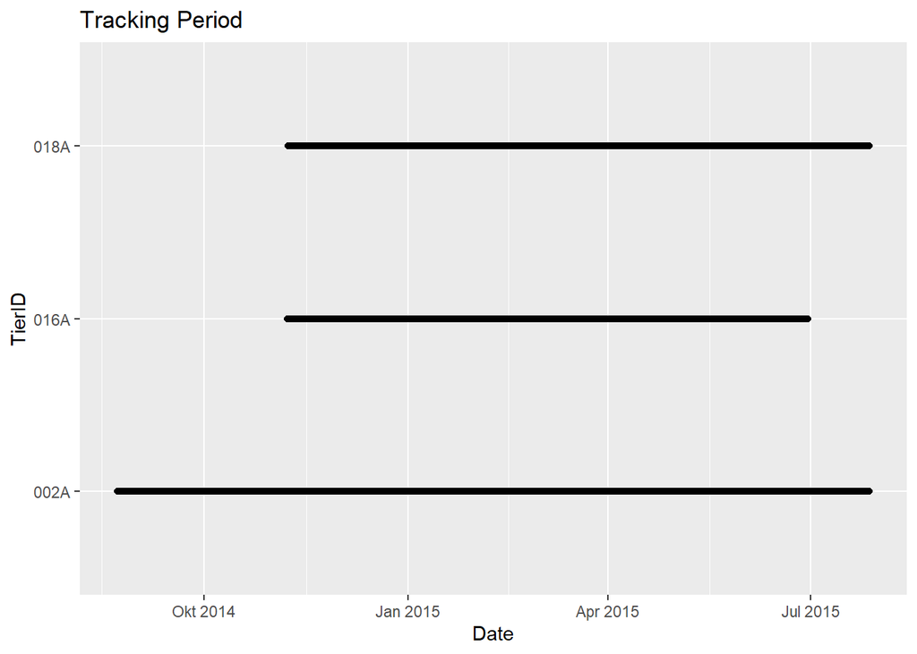

```r
ggplot(wildschwein_BE, aes(DatetimeUTC,TierID))+
  geom_point()+
  labs(title = "Tracking Period",
       x="Date"
       )
```

Overall three individuals were tracked concurrently over different time spans from august 2014 until July 2015. Animal 016A and 018A were tracked for a shorter time period than animal 002A.

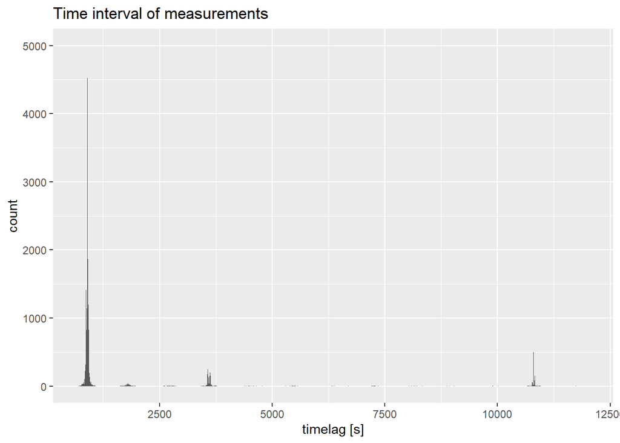

```r
ggplot(wildschwein_BE,aes(timelag))+
  geom_histogram(binwidth = 5)+
  xlim(c(700,12000))+
  ylim(c(0,5000))+
  labs(x= "timelag [s]",
       title= "Time interval of measurements")
```

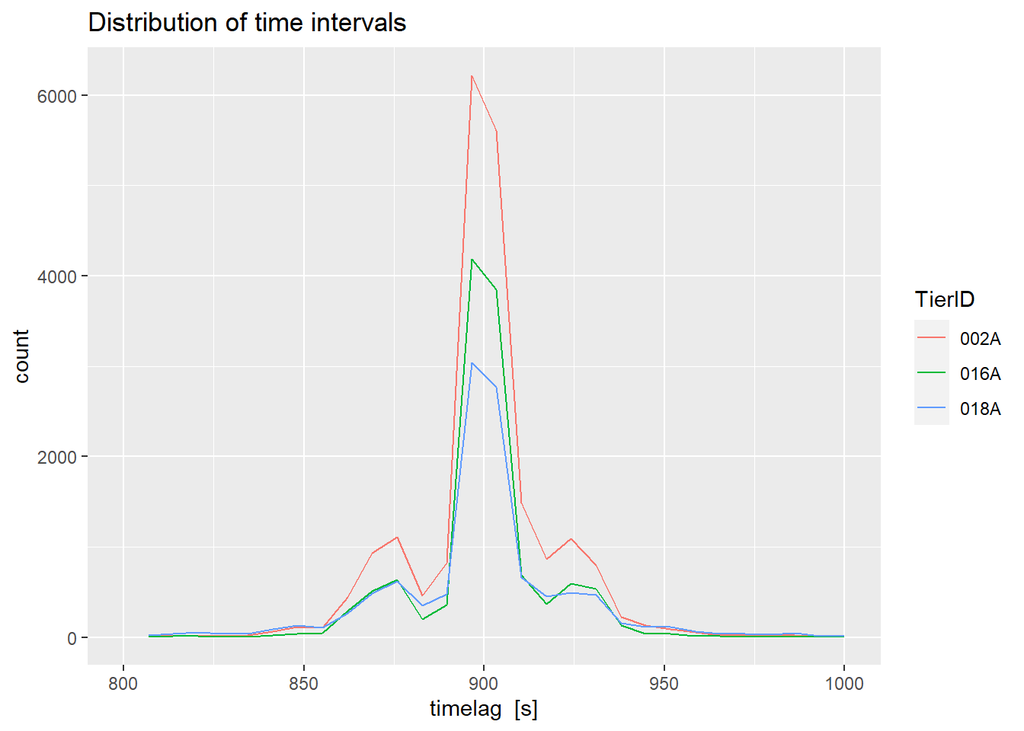

```r
ggplot(wildschwein_BE, aes(timelag, colour= TierID))+
  geom_freqpoly()+
  xlim(c(800, 1000))+
  labs(x="timelag  [s]",
       title= "Distribution of time intervals")
```

The histogram shows that most of the time intervals are between 800 and 1000s and only few are greater than 1000. The second Graph shows the distribuiton of the “timelag” for every animal (Tier ID)

Task 3: Deriving movement parameters I: Speed

```r
wildschwein_BE$steplength<-sqrt((wildschwein_BE$E-lead(wildschwein_BE$E,1))^2+(wildschwein_BE$N-lead(wildschwein_BE$N,1))^2)

wildschwein_BE$speed<-wildschwein_BE$steplength/wildschwein_BE$timelag
str(wildschwein_BE)
```

```
## sf [51,246 x 10] (S3: sf/spec_tbl_df/tbl_df/tbl/data.frame)
##  $ TierID     : chr [1:51246] "002A" "002A" "002A" "002A" ...
##  $ TierName   : chr [1:51246] "Sabi" "Sabi" "Sabi" "Sabi" ...
##  $ CollarID   : num [1:51246] 12275 12275 12275 12275 12275 ...
##  $ DatetimeUTC: POSIXct[1:51246], format: "2014-08-22 21:00:12" "2014-08-22 21:15:16" ...
##  $ E          : num [1:51246] 2570409 2570402 2570394 2570379 2570390 ...
##  $ N          : num [1:51246] 1204752 1204863 1204826 1204817 1204818 ...
##  $ geometry   :sfc_POINT of length 51246; first list element:  'XY' num [1:2] 2570409 1204752
##  $ timelag    : int [1:51246] 904 927 924 855 888 903 898 916 914 888 ...
##  $ steplength : num [1:51246] 111.1 38.2 16.8 10.8 7.4 ...
##  $ speed      : num [1:51246] 0.12291 0.04125 0.01816 0.01261 0.00834 ...
##  - attr(*, "spec")=
##   .. cols(
##   ..   TierID = col_character(),
##   ..   TierName = col_character(),
##   ..   CollarID = col_double(),
##   ..   DatetimeUTC = col_datetime(format = ""),
##   ..   E = col_double(),
##   ..   N = col_double()
##   .. )
##  - attr(*, "problems")=<externalptr>
##  - attr(*, "sf_column")= chr "geometry"
##  - attr(*, "agr")= Factor w/ 3 levels "constant","aggregate",..: NA NA NA NA NA NA NA NA NA
##   ..- attr(*, "names")= chr [1:9] "TierID" "TierName" "CollarID" "DatetimeUTC" ...
```

Speed unit is m/s, because the coordinates are in meters and the timelag is in seconds. Depending on the purpose it could make sense to calculate m/min or km/h.

Task 4: Cross-scale movement analysis

```r
caro <- read_delim("caro60.csv",",")
caro <- st_as_sf(caro, coords = c("E", "N"), crs = 2056, remove = FALSE)
str(caro)
```

```
## sf [200 x 7] (S3: sf/spec_tbl_df/tbl_df/tbl/data.frame)
##  $ TierID     : chr [1:200] "010C" "010C" "010C" "010C" ...
##  $ TierName   : chr [1:200] "Caro" "Caro" "Caro" "Caro" ...
##  $ CollarID   : num [1:200] 13973 13973 13973 13973 13973 ...
##  $ DatetimeUTC: POSIXct[1:200], format: "2015-09-15 08:07:00" "2015-09-15 08:08:00" ...
##  $ E          : num [1:200] 2570589 2570573 2570536 2570518 2570499 ...
##  $ N          : num [1:200] 1205095 1205096 1205099 1205115 1205130 ...
##  $ geometry   :sfc_POINT of length 200; first list element:  'XY' num [1:2] 2570589 1205095
##  - attr(*, "spec")=
##   .. cols(
##   ..   TierID = col_character(),
##   ..   TierName = col_character(),
##   ..   CollarID = col_double(),
##   ..   DatetimeUTC = col_datetime(format = ""),
##   ..   E = col_double(),
##   ..   N = col_double()
##   .. )
##  - attr(*, "problems")=<externalptr>
##  - attr(*, "sf_column")= chr "geometry"
##  - attr(*, "agr")= Factor w/ 3 levels "constant","aggregate",..: NA NA NA NA NA NA
##   ..- attr(*, "names")= chr [1:6] "TierID" "TierName" "CollarID" "DatetimeUTC" ...
```

Reduction of granularity

```r
caro_3<-slice(caro,seq(from= 1, to= 200, by =3))
caro_6<-slice(caro,seq(from= 1, to= 200, by =6))
caro_9<-slice(caro,seq(from= 1, to= 200, by =9))
```

Caluclation of timelag, steplength and speed

```r
##caro
caro$timelag<-as.integer(difftime(lead(caro$DatetimeUTC),caro$DatetimeUTC, units = "secs"))

caro$steplength<-sqrt((caro$E-lead(caro$E,1))^2+(caro$N-lead(caro$N,1))^2)

caro$speed<-caro$steplength/caro$timelag

##caro_3
caro_3$timelag<-as.integer(difftime(lead(caro_3$DatetimeUTC),caro_3$DatetimeUTC, units = "secs"))

caro_3$steplength<-sqrt((caro_3$E-lead(caro_3$E,1))^2+(caro_3$N-lead(caro_3$N,1))^2)

caro_3$speed<-caro_3$steplength/caro_3$timelag

##caro_6
caro_6$timelag<-as.integer(difftime(lead(caro_6$DatetimeUTC),caro_6$DatetimeUTC, units = "secs"))

caro_6$steplength<-sqrt((caro_6$E-lead(caro_6$E,1))^2+(caro_6$N-lead(caro_6$N,1))^2)

caro_6$speed<-caro_6$steplength/caro_6$timelag

##caro_9
caro_9$timelag<-as.integer(difftime(lead(caro_9$DatetimeUTC),caro_9$DatetimeUTC, units = "secs"))

caro_9$steplength<-sqrt((caro_9$E-lead(caro_9$E,1))^2+(caro_9$N-lead(caro_9$N,1))^2)

caro_9$speed<-caro_9$steplength/caro_9$timelag
```

Visual interpretation

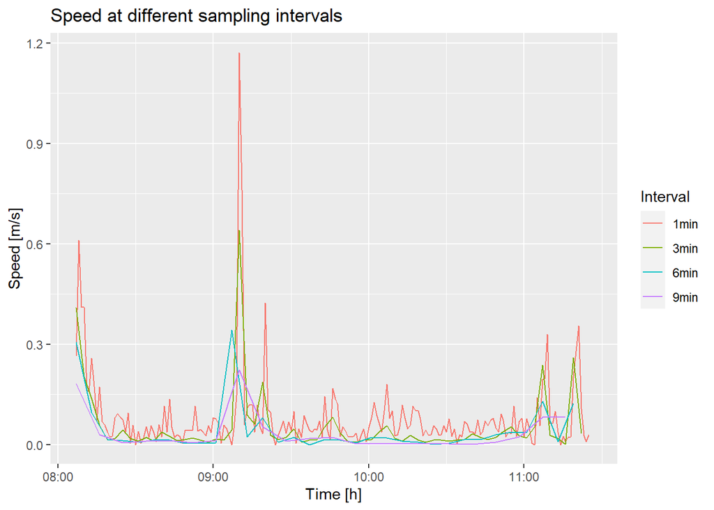

```r
caro$Interval<-"1min"
caro_3$Interval<-"3min"
caro_6$Interval<-"6min"
caro_9$Interval<-"9min"

allcaro<-rbind.data.frame(caro,caro_3,caro_6,caro_9)%>%
  group_by(Interval)

ggplot(allcaro, aes(DatetimeUTC,speed, col= Interval))+
  geom_line()+
  labs(title= "Speed at different sampling intervals",
       x= "Time [h]",
       y= "Speed [m/s]",
  )
```

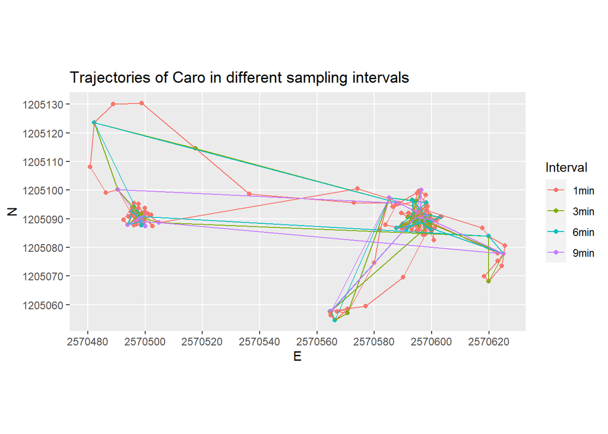

```r
ggplot(allcaro, aes(E,N,colour = Interval))+
  geom_sf()+
  geom_path()+
  coord_sf(datum =2056)+
  labs(title = "Trajectories of Caro in different sampling intervals")
```

The lineplot shows, that with lower granularity more information gets lost. In this example, the speed peaks at 9:10 decrease drastically. Also the speed variations are not represented well in the case of 6 and 9 min sampling intervals. The second plot shows also, that some information gets lost. The hot spots are represented well even with the low granularity but some other parts of the route are lost.

Task 5: Deriving movement parameters II: Rolling window functions

```r
library(zoo)

example <- rnorm(10)
rollmean(example,k = 3,fill = NA,align = "left")
```

```
##  [1]  0.03496793 -0.92947670 -0.66983319 -1.04607676 -0.50741462 -1.28070970
##  [7] -1.04986627 -0.58975260          NA          NA
```

```r
rollmean(example,k = 4,fill = NA,align = "left")
```

```
##  [1] -0.4180609 -0.8486945 -0.6910587 -0.8248478 -1.1121192 -0.9760835
##  [7] -0.4826047         NA         NA         NA
```

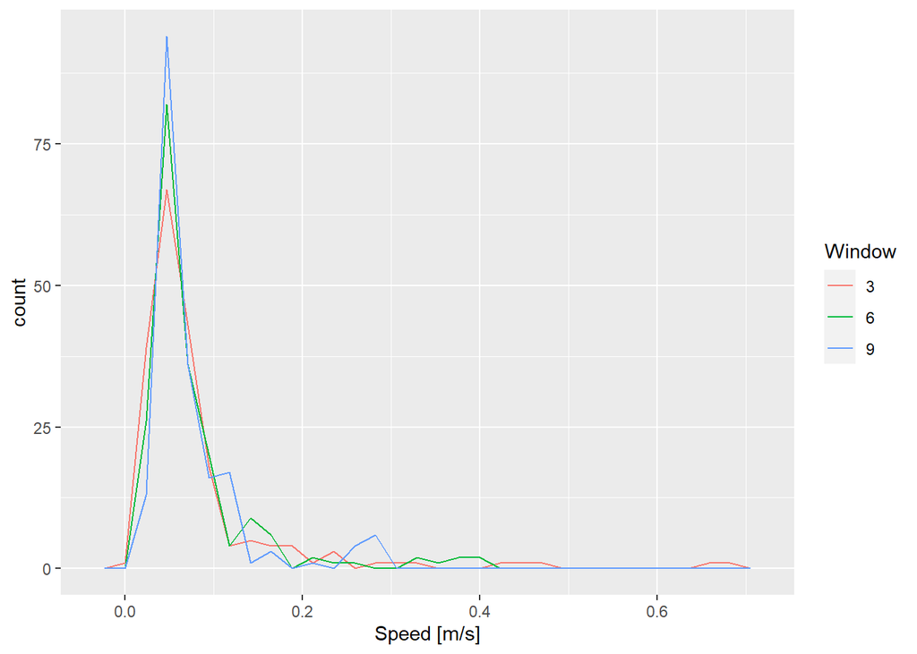

```r
caro_3_2<-as.data.frame(rollmean(caro$speed, k =3, fill= NA, align = "left"))
caro_3_2$interval<-"3"
colnames(caro_3_2)<-c("Speed","Window")

caro_6_2<-as.data.frame(rollmean(caro$speed, k =6, fill = NA, align = "left"))
caro_6_2$interval<-"6"
colnames(caro_6_2)<-c("Speed","Window")


caro_9_2<-as.data.frame(rollmean(caro$speed, k =9, fill = NA, align = "left"))
caro_9_2$interval<-"9"
colnames(caro_9_2)<-c("Speed","Window")
caro_2<-rbind.data.frame(caro_3_2,caro_6_2,caro_9_2)

ggplot(caro_2, aes(Speed, col=Window))+
  geom_freqpoly()+
  labs(x="Speed [m/s]")
```

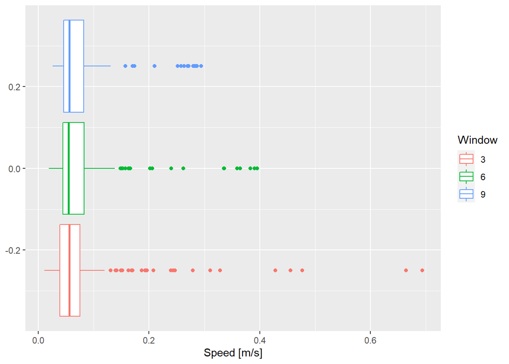

```r
ggplot(caro_2, aes(Speed, col=Window))+
  geom_boxplot()+
  labs(x="Speed [m/s]")
```

The first plot shows, with smaller moving windows (k), the flatter the curve. More different values for speed are shown. Very high or very low values are better represented with a small moving window, as shown in the second graph (boxplot).